# Homework 2: Sampling and Iteration in the Tidyverse

Quentin D’Arcy

9/24/2020

# Set 1: Sample Properties

### 1a) Say “Vole Vasopressin” 10 times fast

I made it about 2 in before calling it Volsopressin, so my future as a vole doctor isn’t looking promising…

### 1b)What is the mean, median, sd, and IQR of the vole sample

```r
#Set up the vole vasopressin data frame
vole_vaso <- c(98,96,94,88,86,82,77,74,70,60,
           59,52,50,47,40,35,29,13,6,5)

#Find the various sample parameters
vole_param <- c(mean(vole_vaso),
                median(vole_vaso),
                sd(vole_vaso),
                IQR(vole_vaso))
vole_param
```

```
## [1] 58.05000 59.50000 29.75244 44.25000
```

Here are the parameters for these Vole Vasopressin levels

- **Mean** = 58.05
- **Median** = 59.5
- **Standard Deviation** = 29.75
- **IQR** = 44.25

### 1c) What is the standard error of the mean (do this with a formula!)

Using the formula SE = sd/sqrt(n)

```r
#Using the formula SE = sd/sqrt(n) calculate the SE of the mean
vole_SE <- (sd(vole_vaso)/sqrt(length(vole_vaso)))
vole_SE
```

```
## [1] 6.652849
```

Here we have the Standard Error of the Mean:

- **Standard Error of the Mean** = 6.65

### 1d) What does the standard error of the mean tell you about our estimate of the mean values of the population of Vole Vasopressin

Assuming that this sample of vole vasopressin levels is reasonably representative of the population, we have the following Confidence Intervals:

**66% Confidence Interval** : 51.4 to 64.7

**95% Confidence Interval** : 44.74 to 71.36

Here we can say that if we were to sample the population many, many times then 2/3rds of the time our 66% confidence interval will contain the true value of the mean.

We can say the same thing for the 95% confidence interval in that 95% of the time our 95% confidence interval will contain the true value of the mean

# Set 2: Sample size for upper quartiles

### 2a) Use sample() to get just one resample with a sample size of 10. What is its Upper Quartile

```r
#Calculate the resample
vole_sample <- sample(vole_vaso, size = 10, replace = TRUE )
vole_sample
```

```
##  [1] 82 40 94 96 82 35 60 13 13  5
```

```r
#Calculate the upper quartile
vole_Upper_Quartile <- quantile(vole_vaso, probs = .75)
vole_Upper_Quartile
```

```
## 75%
##  83
```

Here we have a single re-sampling of the original sample of the population. To do this the Vole Vasopressin data was randomly sampled 10 times (with replacement) to create a new vector.

### 2b) Build an initial data frame for simulations with the sample sizes 5 through 20

```r
vole_sim <- data.frame(sample_size = 5:20)
vole_sim
```

```
##    sample_size
## 1            5
## 2            6
## 3            7
## 4            8
## 5            9
## 6           10
## 7           11
## 8           12
## 9           13
## 10          14
## 11          15
## 12          16
## 13          17
## 14          18
## 15          19
## 16          20
```

### 2c) Use this data frame to get simulated upper quartiles at each sample size 1,000 times

```r
vole_UQ_sim <- vole_sim %>%

  #for each sample size
  rowwise() %>%

  #Replicate calculating the upper quartile 1000 times in a normal distribution
  #based around the mean and sd of vole_vaso and have it spit out a df

  summarize(sample_size,
            Upper_Quartile = replicate(1000, quantile(rnorm(n = sample_size,
                                                   mean = mean(vole_vaso),
                                                   sd = sd(vole_vaso)), probs = .75)) %>% mean())

gt (vole_UQ_sim) %>%
  #Set up the tab header
  tab_header(
    title = "Upper Quartile per Sample Size") %>%

  #Align it to the center
  opt_align_table_header(align = "center") %>%

  #Label the columns
  cols_label(Upper_Quartile = "Upper Quartile",
             sample_size = "Sample Size") %>%

  #Stripe the rows to make it more readable
  opt_row_striping(row_striping = TRUE)
```

Upper Quartile per Sample Size

| Sample Size | Upper Quartile |
| --- | --- |
| 5 | 72.34817 |
| 6 | 73.51779 |
| 7 | 73.94622 |
| 8 | 75.33201 |
| 9 | 74.88227 |
| 10 | 75.26993 |
| 11 | 75.53345 |
| 12 | 75.89568 |
| 13 | 76.02143 |
| 14 | 75.74844 |
| 15 | 76.31650 |
| 16 | 76.55573 |
| 17 | 76.50862 |
| 18 | 76.99752 |
| 19 | 76.11496 |
| 20 | 76.44097 |

Here have our table of upper quartiles at each sample size up to 20 samples

### 2d) With ggplot, make a guess as to the best sample size for estimating the upper quartile of the population

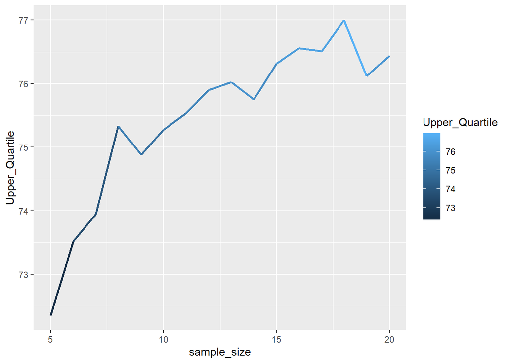

```r
#Plot the table above
UQ_Plot <- ggplot(data = vole_UQ_sim,
                        mapping =aes(x = sample_size,
                                     y = Upper_Quartile,
                                     color = Upper_Quartile,
                                     fill = Upper_Quartile))
UQ_Plot +
  geom_line(size = 1)
```

So here is the data that we’ve collected so far across our 20 sample range, and as we can see there is still alot of fluctation in the values for the UQ of this data set. I believe that a line graph here is the easiest way to view this data pattern and included color for UQ as a quick visual

This suggests that we aren’t quite at our optimal sample size. To figure out what it is I’m going to extend our simulation out to 200 samples

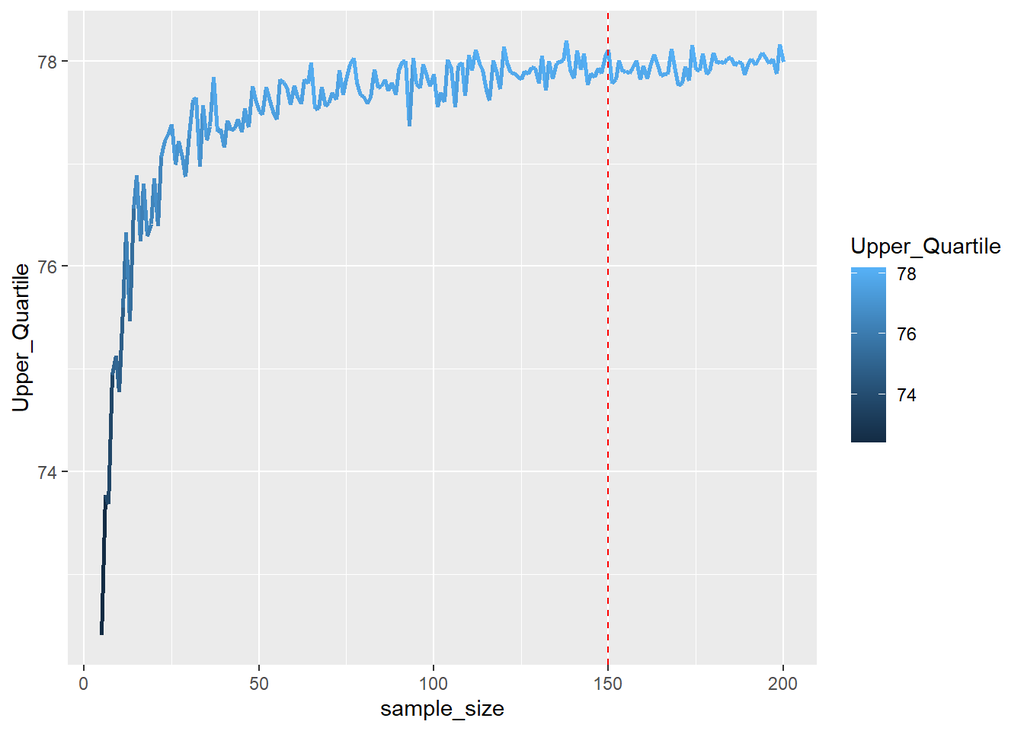

```r
#Set up our inital df for sample sizes 5 through 200
vole_sim <- data.frame(sample_size = 5:200)

vole_UQ_sim <- vole_sim %>%

  #for each sample size
  rowwise() %>%

  #Replicate calculating the upper quartile 1000 times in a normal distribution
  #based around the mean and sd of vole_vaso and have it spit out a df

  summarize(sample_size,
            Upper_Quartile = replicate(1000, quantile(rnorm(n = sample_size,
                                                   mean = mean(vole_vaso),
                                                   sd = sd(vole_vaso)), probs = .75)) %>% mean())
#Plot the table above
UQ_Plot <- ggplot(data = vole_UQ_sim,
                        mapping =aes(x = sample_size,
                                     y = Upper_Quartile,
                                     color = Upper_Quartile,
                                     fill = Upper_Quartile))
#take a look at a line graph with the 50 sample mark
UQ_Plot +
  geom_line(size = 1) +
  geom_vline(linetype = "dashed",
             color = "red",
             xintercept = 150)
```

With this plot we can see that the UQ data seems to start to level out at about 78 around a sample size of 150 samples.

This means that this would be the (guesstimated) sample size where we balance precision with the excessive collection of samples.

### 2e) Plot the SE of the estimate of the upper quantile by sample size

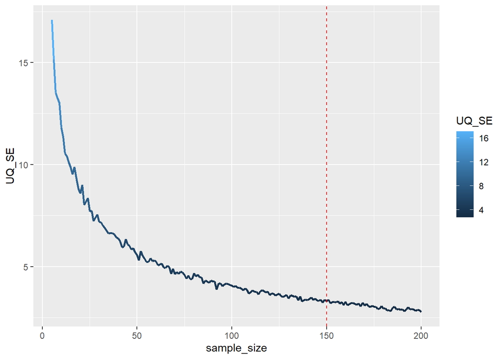

```r
#Set up our inital df for sample sizes 5 through 200
vole_sim <- data.frame(sample_size = 5:200)

vole_UQ_sim <- vole_sim %>%

  #for each sample size
  rowwise() %>%

  #Replicate calculating the standard error of the UQ 1000 times in a normal distribution
  #based around the mean and sd of vole_vaso and have it spit out a df

  summarize(sample_size,
            UQ_SE = replicate(1000, quantile(rnorm(n = sample_size,
                                                   mean = mean(vole_vaso),
                                                   sd = sd(vole_vaso)), probs = .75)) %>% sd())
#Plot the table above
UQ_Plot <- ggplot(data = vole_UQ_sim,
                        mapping =aes(x = sample_size,
                                     y = UQ_SE,
                                     color = UQ_SE,
                                     fill = UQ_SE))
#take a look at a line graph with the 50 sample mark
UQ_Plot +
  geom_line(size = 1) +
  geom_vline(linetype = "dashed",
             color = "red",
             xintercept = 150)
```

Here we have the graph of the SE of the UQ across different sample sizes.

Again, we see a similar pattern to the regular UQ data in that the curve seems to level off. This time it levels off around a SE of the UQ of about 3.5 (I feel that this line plot is the best way to visualize it)

I would feel comfortable again with a sample size around 150 samples, however in this case I might even push that number a bit more towards 200 as we still see a somewhat significant decrease in SE towards that end of the graph.

All things considered this graph matches well with our previous UQ vs Sample Size graph

# Set 3: GGplot

## 3a) A little bit of setup

```r
#libraries

#Our best friend for all things piping and simming
library(dplyr)

#A package that is used to read rectangular data (e.g., outputed excel tables like .csv)
library(readr)

#Plotting
library(ggplot2)

#A package full of tools that help deal with factors (i.e., categorical variables)
library(forcats)

#set the ggplot theme
theme_set(theme_bw(base_size=12))

#import the tidy'd ice melting data in to a df
ice <- read_csv("http://biol607.github.io/homework/data/NH_seaice_extent_monthly_1978_2016.csv") %>%

  #Add a Month Name column and reorder to go by month
  mutate(Month_Name = factor(Month_Name),
         Month_Name = fct_reorder(Month_Name, Month))
```

### 3b) Make a boxplot showing variability in sea ice extent every month

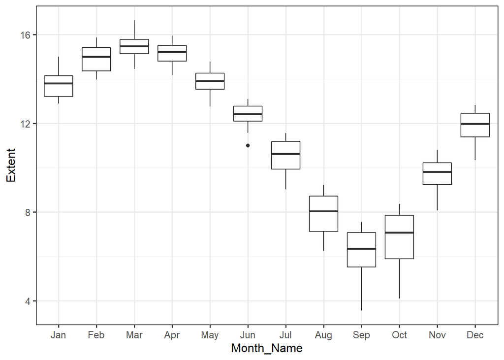

```r
#Plot the table above
ice_box <- ggplot(data = ice,
                        mapping = aes(x = Month_Name,
                                     y = Extent))

#Take a look at the boxplot (ggplot is the absolute best)
ice_box +
  geom_boxplot()
```

Here is our boxplot. Each box represents data taken from 1978 to 2016

### 3c) Use dplyr to get the annual minimum sea ice extent and plot it by year

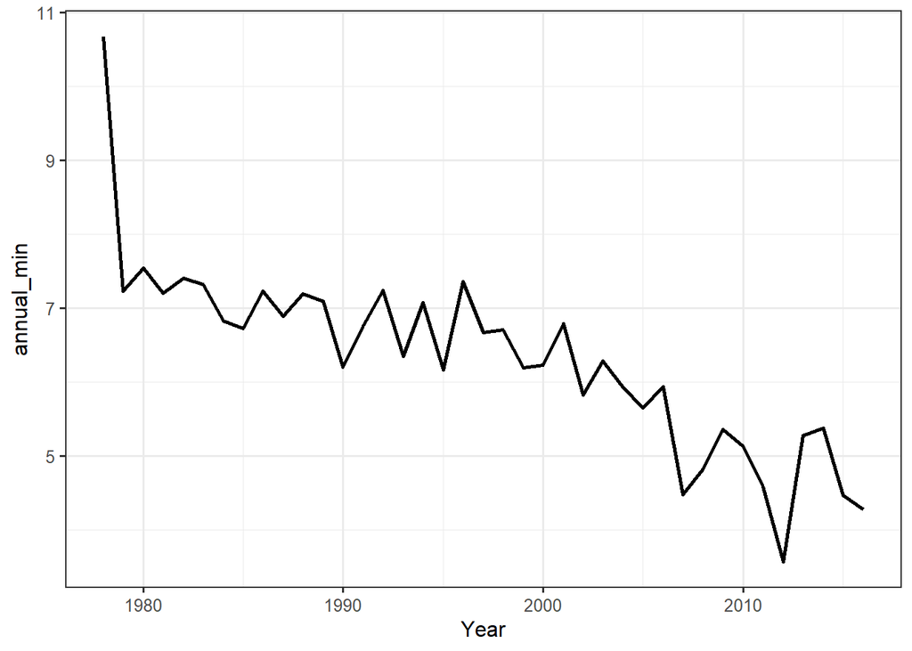

```r
#Create a dataframe to work with
ice_year <- ice %>%

  #Group by the year
  group_by(Year) %>%

  #Find the minimum for that year
  summarize(annual_min = unique(min(Extent)))

#Plot the annual min across year
UQ_Plot <- ggplot(data = ice_year,
                        mapping =aes(x = Year,
                                     y = annual_min))

#take a look at a line graph with the 50 sample mark
UQ_Plot +
  geom_line(size = 1)
```

Here is a line graph showing the decrease in the annual minimum ice extent for 1978 to 2016

### 3d) Plot sea ice by year with different lines for different months then use cut interval to show plots by season

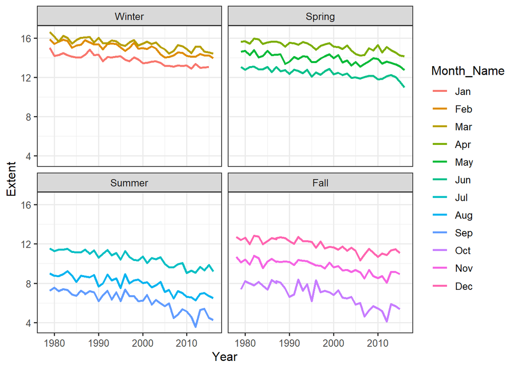

```r
#Create a df to work with
ice_cut <- ggplot(data = ice,
                  mapping = aes(x = Year,
                                y = Extent))

#plot it with a line plot setting the color equal to the Month_Name
ice_cut +
  geom_line(size = 1,
            aes(color = Month_Name))+
  #Set a discrete color for each line plot
  scale_color_discrete() +
  #cut the facet in to seasons and label accordingly
  facet_wrap(~cut_interval(Month,
                           n = 4,
                           labels = c("Winter", "Spring", "Summer", "Fall")))
```

### 3e) Make a line plot of sea ice by month with different lines as differnt years

[figure not shown]

```r
#Create a df to work with
ice_cut <- ggplot(data = ice,
                  mapping = aes(x = Month_Name,
                                y = Extent,
                                color = Year,
                                group = Year))

#Set up a different theme
theme_set(theme_dark(base_size = 12))

#plot it with a line plot setting the color equal to the Month_Name
ice_cut +
  geom_line()+
  scale_color_viridis_c()+
  labs(title = "Arctic Sea Ice Size by Year: {frame_time",
       x = "Month",
       y = "Extent",
       color = "Year")
```

### 3f) Animate it!

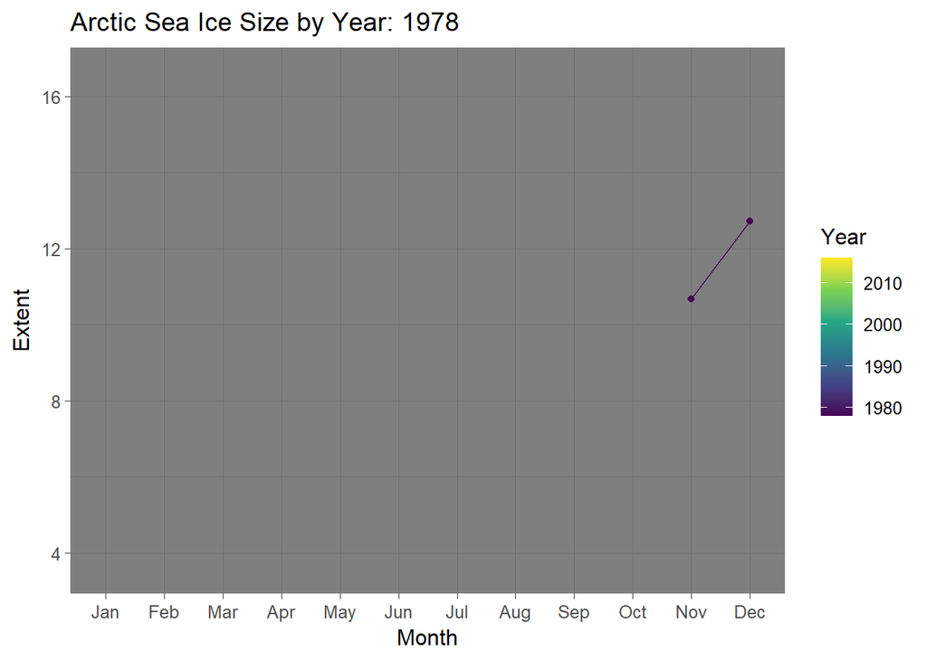

```r
#load the library
library(gganimate)
library(gifski)
library(transformr)
#Create a df to work with
ice_cut <- ggplot(data = ice,
                  mapping = aes(x = Month_Name,
                                y = Extent,
                                color = Year,
                                group = Year))

#Set up a different theme
theme_set(theme_dark(base_size = 12))

#plot it with a line plot setting the color equal to the Month_Name
ice_cut +
  geom_line()+
  scale_color_viridis_c()+
  labs(title = "Arctic Sea Ice Size by Year: {frame_along}",
       x = "Month",
       y = "Extent",
       color = "Year") +
  transition_reveal(Year)+
  geom_point(aes(group = seq_along(Year))) +
  ease_aes('linear')
```